# The Impact of Technology Access on Earnigs

Group 06

January 28, 2019

# 0. Research Question and Variable Selection

**Research Questions:**

With a past of racial inequality in the southern states it would be interesting to examine how race/ethnicity is related to access to the internet and other technologies and how not having or having access could effect a persons earnings. This can be explored via the following research questions:

1. In the state of Alabama, how to earnings vary by access to the internet/technology?
2. Does the internet/technology premium vary by race and ethnicity?

**Variable Selection**:

To answer the research questions, this study looks at the variables which will reveal the demographic characteristics - such as “age” or “race”; socioeconomic status - such as “employment status” or “wage”; and the access to techonlogy - such as “access to internet.”

- The following variables will be included in this study. (Some other varialbes will be used as connector when joining tables but will not be included in the final dataframe.)
1. AGEP # Age: 0#99
2. SEMP # Self-employment income past 12 months (signed)
3. WAGP # Wages or salary income past 12 months
4. HISP # Recoded detailed Hispanic origin
5. NATIVITY # Nativity
6. PERNP # Total person’s earnings
7. RAC1P # Recoded detailed race code
8. RACAIAN # American Indian and Alaska Native recode
9. RACASN # Asian recode
10. RACBLK # Black or African American recode
11. RACNH # Native Hawaiian recode
12. RACWHT # White recode
13. SCHL # Educational attainment
14. WAOB # World area of birth
15. WKW #Weeks worked during past 12 months
16. ACCESS # Access to the Internet

# 1. System Setup

The following chunk of code (hidden from this html file) are applied to clean the working environment. There libraries and one external function are loaded.

Three loaded libraries are:

1. tidyverse
2. here
3. DataExplorer

One external function was programmed by the team. It is located at folder of “code”, and the function is:

1. function_convert_CSV_to_vector.R

# 2. Data Cleaning

## 2.1 Import the raw data

Import the raw data of personal income (ss16pal) into the dataframe of “base.”

```r
#load the persional data to variable Base
base <- read_csv(here('raw_data','ss16pal.csv'))%>%
  select(SERIALNO, #Serial Number to link House Hold and Personal data
         AGEP,  # Age: 0#99
         SEMP,  # Self-employment income past 12 months (signed)
         WAGP,  # Wages or salary income past 12 months
         HISP,  # Recoded detailed Hispanic origin
         NATIVITY,  # Nativity
         PERNP, # Total person's earnings
         RAC1P, # Recoded detailed race code
         RACAIAN, # American Indian and Alaska Native recode
         RACASN,  # Asian recode
         RACBLK,  # Black or African American recode
         RACNH, # Native Hawaiian recode
         RACWHT,  # White recode
         SCHL,   # Educational attainment
         WAOB,  # World area of birth
         WKW)   #Weeks worked during past 12 months
```

Import the household level information (ss16hal) about internet access and merge the data into “base.”

```r
#Link the house hould data
househould <- read_csv(here('raw_data','ss16hal.csv'))%>%
  select(SERIALNO, #Serial Number to link House Hold and Personal data
        ACCESS # Access to the Internet
  )
base <- base %>% left_join(househould) %>% select(-SERIALNO)
rm(househould)
```

## 2.2 Structure of raw data

Based on the first observation below, some ordinary data will be converted into numerical type, and some categorical data will be converted into factor type.

```
Classes ‘spec_tbl_df’, ‘tbl_df’, ‘tbl’ and 'data.frame':    47659 obs. of  16 variables:
 $ AGEP    : chr  "84" "84" "78" "46" ...
 $ SEMP    : chr  "0000000" "0000000" "0000000" "0000000" ...
 $ WAGP    : chr  "0000000" "0000000" "0027300" "0065000" ...
 $ HISP    : chr  "01" "01" "01" "01" ...
 $ NATIVITY: num  1 1 1 1 1 1 1 1 1 1 ...
 $ PERNP   : chr  "000000000" "000000000" "000027300" "000065000" ...
 $ RAC1P   : num  1 1 1 1 1 1 1 1 1 1 ...
 $ RACAIAN : num  0 0 0 0 0 0 0 0 0 0 ...
 $ RACASN  : num  0 0 0 0 0 0 0 0 0 0 ...
 $ RACBLK  : num  0 0 0 0 0 0 0 0 0 0 ...
 $ RACNH   : num  0 0 0 0 0 0 0 0 0 0 ...
 $ RACWHT  : num  1 1 1 1 1 1 1 1 1 1 ...
 $ SCHL    : chr  "19" "21" "19" "20" ...
 $ WAOB    : num  1 1 1 1 1 1 1 1 1 1 ...
 $ WKW     : num  NA NA 1 1 NA NA NA NA NA 1 ...
 $ ACCESS  : num  1 1 3 1 1 1 1 1 1 1 ...
```

## 2.3 Convert the variable types

Convert the categorical data into factor type and numetical data into numeric type. The factorial data in this dataframe will keep its representative code instead of the category name to save the memory space.

```r
#conver the catagorical variable type
base <- base %>% mutate(HISP= as.factor(HISP),
                        RAC1P= as.factor(RAC1P),
                        RACAIAN = as.factor(RACAIAN),
                        RACASN = as.factor(RACASN),
                        RACBLK = as.factor(RACBLK),
                        RACNH = as.factor(RACNH),
                        RACWHT = as.factor(RACWHT),
                        SCHL = as.factor(SCHL),
                        WAOB = as.factor(WAOB),
                        WKW = as.factor(WKW),
                        ACCESS = as.factor(ACCESS),
                        NATIVITY = as.factor(NATIVITY)
                        )
#conver the numeric variable type
base <- base %>% mutate(AGEP = as.numeric(AGEP),
                        SEMP= as.numeric(SEMP),
                        WAGP= as.numeric(WAGP),
                        PERNP= as.numeric(PERNP)
                        )
```

Replace the factor levels to the contents in the survery question for easy understanding.

```r
levels(base$ACCESS) <- convertCSV2Factor("ACCESS")
levels(base$HISP) <- convertCSV2Factor("HISP")
levels(base$RAC1P) <- convertCSV2Factor("RAC1P")
levels(base$RACAIAN) <- convertCSV2Factor("RACAIAN")
levels(base$RACASN) <- convertCSV2Factor("RACASN")
levels(base$RACBLK) <- convertCSV2Factor("RACBLK")
levels(base$RACNH) <- convertCSV2Factor("RACNH")
levels(base$RACWHT) <- convertCSV2Factor("RACWHT")
levels(base$SCHL) <- convertCSV2Factor("SCHL")
levels(base$SEX) <- convertCSV2Factor("SEX")
levels(base$WKW) <- convertCSV2Factor("WKW")
levels(base$WAOB) <- convertCSV2Factor("WAOB")
levels(base$NATIVITY) <- convertCSV2Factor("NATIVITY")
```

==================

# 4. Criteria for filtering the data

**1. Age range:**

The ages of cases covered in the survey are ranging from **0 year old to 93 years old**. There is **no missing value** under the age category.

According to the regulation from US Department of Labor, the legal working age is 14 (for most non-agricultural work), and the early retirement age is 62. This study will looks at the **age group of 14~62 years old (Data Filtering Criteria 1)**.

```r
base <- base %>%
        mutate( age_group = case_when(
                            AGEP < 14 ~ "Other ages (exclude)",
                            AGEP >= 14 & AGEP <= 62 ~ "Age 14-62 (include)",
                            AGEP > 62 ~ "Other ages (exclude)"
        ))
base$age_group <- as.factor(base$age_group)
```

Remove the records which are out of the age group of 14 to 62.

`r`r base <- base %>% filter(AGEP>=14 & AGEP <= 62) base$age_group <- NULL

**2. Earnings:**

`r`r base <- base %>% filter(WAGP<54000 & WAGP > 11600)

The selection of full time employee is arbitrary. This study includes groups which **work more than 40 weeks a years (Data Filtering Criteria 4)**. (Please be noted: More studies shold be considered in decideing the threshold separating full-time and part-time employee. This study set the 40 week/year as the threshold for now.)

==================

# 6. Building Models

## 6.1 Examine access to the internet and its relation to earnings.

`r`r base %>% select(ACCESS) %>% summary()

```
         ACCESS
 Paid Access:8310
 Free Access: 250
 No Access  : 948
 NA's       : 109
```

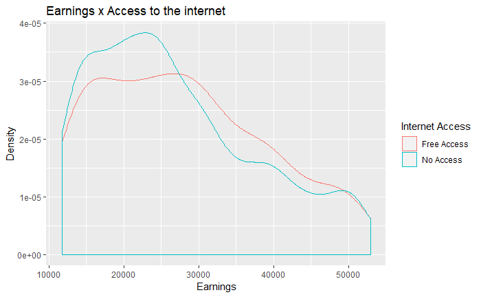

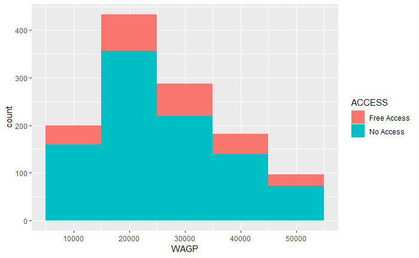

`r`r base %>%  
filter(!is.na(ACCESS) & ACCESS != Access) %>% group_by(ACCESS, RAC1P) %>% summarise (mean(WAGP),sd(WAGP),min(WAGP),max(WAGP), median(WAGP))

| ACCESS | RAC1P | mean(WAGP) | sd(WAGP) | min(WAGP) | max(WAGP) | median(WAGP) |
| --- | --- | --- | --- | --- | --- | --- |
| Free Access | White | 28350.92 | 10824.968 | 12000 | 52000 | 28000 |
| Free Access | African American | 28240.74 | 11231.293 | 11700 | 52000 | 25000 |
| Free Access | American Indian | 18800.00 | NaN | 18800 | 18800 | 18800 |
| Free Access | Others | 31000.00 | 26870.058 | 12000 | 50000 | 31000 |
| Free Access | Two more | 13666.67 | 1527.525 | 12000 | 15000 | 14000 |
| No Access | White | 28489.07 | 11033.888 | 11800 | 53000 | 26000 |
| No Access | African American | 24930.72 | 10344.866 | 11700 | 52000 | 23000 |
| No Access | American Indian | 23266.67 | 2052.641 | 21000 | 25000 | 23800 |
| No Access | Tribes or Others | 20000.00 | NaN | 20000 | 20000 | 20000 |
| No Access | Asian | 28500.00 | 12020.815 | 20000 | 37000 | 28500 |

[output cut: 2 more lines]

**Building the model**

model_01 <- lm(WAGP ~ free_access, data = base_model) model_01 %>% summary()

```
Call:
lm(formula = WAGP ~ free_access, data = base_model)

Residuals:
   Min     1Q Median     3Q    Max
-16422  -8879  -1951   7049  26049

Coefficients:
                Estimate Std. Error t value Pr(>|t|)
(Intercept)      26950.8      354.7  75.972   <2e-16 ***
free_accessTRUE   1171.2      776.6   1.508    0.132
---
Signif. codes:  0 â€˜***â€™ 0.001 â€˜**â€™ 0.01 â€˜*â€™ 0.05 â€˜.â€™ 0.1 â€˜ â€™ 1

Residual standard error: 10920 on 1196 degrees of freedom
Multiple R-squared:  0.001898,  Adjusted R-squared:  0.001064
F-statistic: 2.274 on 1 and 1196 DF,  p-value: 0.1318
```

`r`r model_02 <- lm(WAGP ~ free_access + hispanic + black, data = base_model) model_02 %>% summary()

```
Call:
lm(formula = WAGP ~ free_access + hispanic + black, data = base_model)

Residuals:
   Min     1Q Median     3Q    Max
-17199  -8348  -2194   6764  27008

Coefficients:
                Estimate Std. Error t value Pr(>|t|)
(Intercept)      28347.5      443.1  63.978  < 2e-16 ***
free_accessTRUE    851.9      770.8   1.105 0.269271
hispanicTRUE     -5355.2     1456.9  -3.676 0.000248 ***
blackTRUE        -2958.3      661.2  -4.474 8.39e-06 ***
---
Signif. codes:  0 â€˜***â€™ 0.001 â€˜**â€™ 0.01 â€˜*â€™ 0.05 â€˜.â€™ 0.1 â€˜ â€™ 1

Residual standard error: 10800 on 1194 degrees of freedom
Multiple R-squared:  0.02529,   Adjusted R-squared:  0.02284
F-statistic: 10.33 on 3 and 1194 DF,  p-value: 1.031e-06
```

```r
base_model <- base_model %>% mutate(ln_earnings = log(WAGP))
```

[output not shown]

# 7. Updates for the week4